# Question

A transformed square-root function, $y=f(x)$, is graphed below. A linear function, $y=L(x)$, is not shown, but it goes through point $(4,-8)$ and has a slope of $\frac{-1}{2}$.

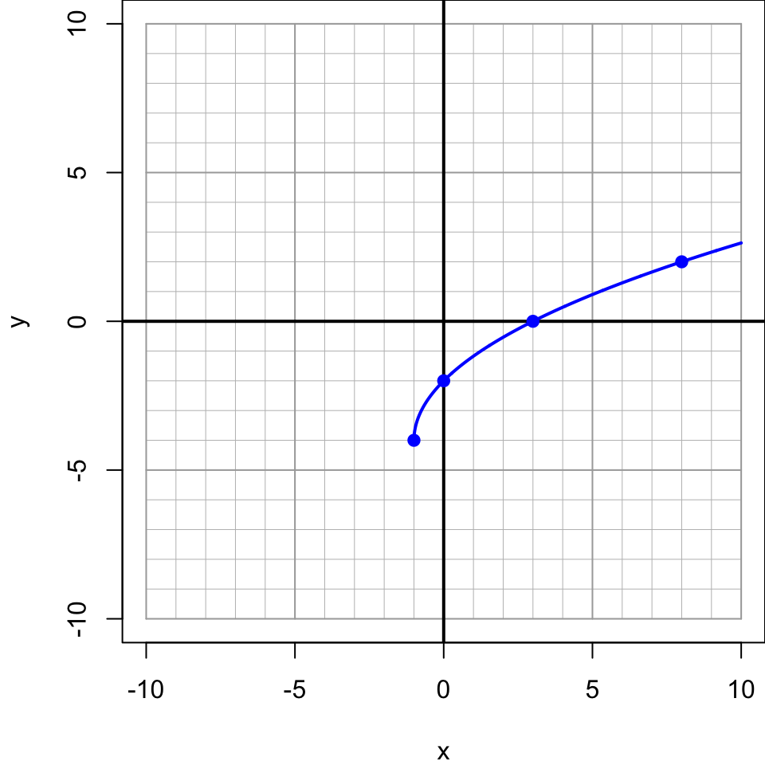

If standard algebraic steps were used to find $x$ values that satisfy equation $f(x)=L(x)$, two possible solutions $x_1$ and $x_2$ will be found such that $x_1<x_2$. Determine the possible solutions, and check if each is valid or extraneous.

- $x_1=$ ##ANSWER1##
- $x_1$ is ##ANSWER2## solution
- $x_2=$ ##ANSWER3##
- $x_2$ is ##ANSWER4## solution

## Answerlist

- -10
- -9
- -8
- -7
- -6
- -5
- -4
- -3
- -2
- -1
- 0
- 1
- 2
- 3
- 4
- 5
- 6
- 7
- 8
- 9
- 10
- an extraneous
- a valid
- -10
- -9
- -8
- -7
- -6
- -5
- -4
- -3
- -2
- -1
- 0
- 1
- 2
- 3
- 4
- 5
- 6
- 7
- 8
- 9
- 10
- an extraneous
- a valid

# Solution

You should be able to complete the picture. Use symmetry to complete the parabola, and use the slope to extend the line.

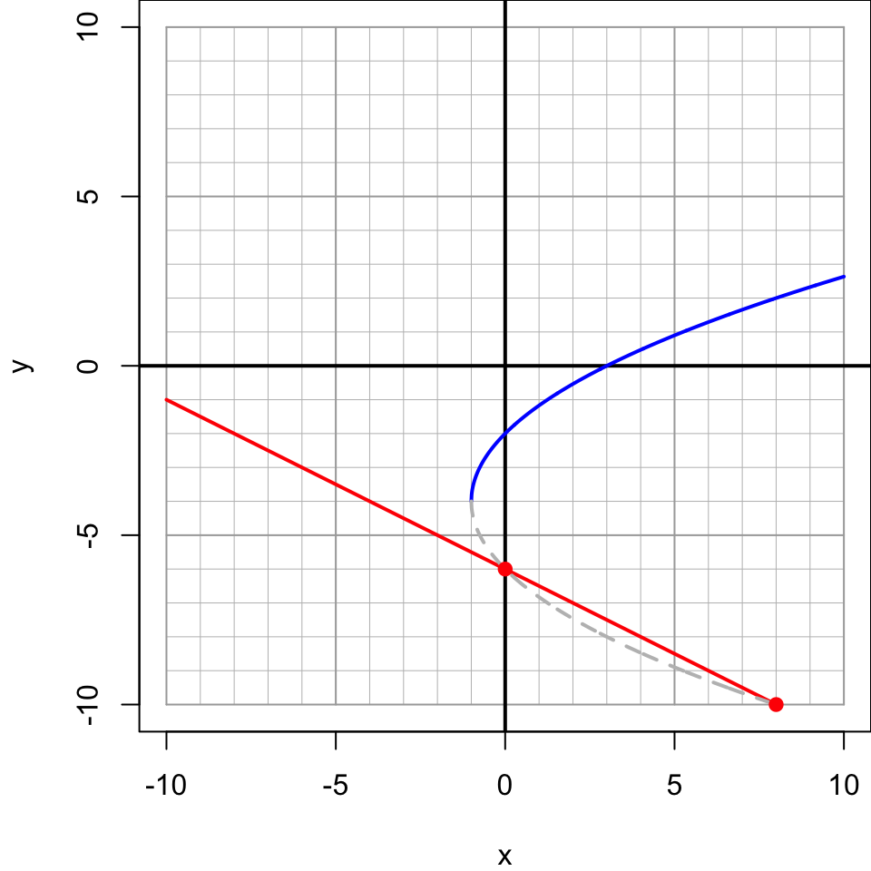

The intersection further left is at $x_1=0$ and it is an extraneous solution.

The intersection further right is at $x_2=8$ and it is an extraneous solution.

I’ll also mention that you could solve approach this problem algebraically. First, examine curve $y=f(x)$ to find the transformations. From those transformations, you can write an algebraic definition of $f(x)$.

$$f(x)=-4+2\sqrt{x+1}$$

To write an algebraic definition of $L(x)$, use point-slope form.

$$L(x)=\frac{-1}{2}(x-4)-8$$

Then set up the equation to solve.

$$-4+2\sqrt{x+1}=\frac{-1}{2}(x-4)-8$$

By doing the algebraic manipulations, you’ll find two possible solutions: $x_1=0$ and $x_2=8$. If you test each in the equation, you’ll find that $x=0$ is an extraneous solution, and $x=8$ is an extraneous solution.

# Meta-information

extype: cloze exclozetype: schoice|schoice|schoice|schoice exsolution: 000000000010000000000|10|000000000000000000100|10 exname: x_find_valext012_graph